# SimiCviz: Visualization and Analysis of Gene Regulatory Networks

## 4.3 Filtering Options

Different GRN methods provide different quality metrics. Adjust filtering based on your method:

```r
# SimiC: Filter by adjusted R² (goodness of fit)

processor_simic <- AUCProcessor(
  weights = simic_weights,
  expression = expr_mat,
  cell_labels = cell_labels,
  adj_r2_list = adjusted_r_squared, # a list length as simic_weights
  qc_type = "adj_r2",
  qc_threshold = 0.7  # Keep targets with R² ≥ 0.7
)

# SCENIC / Pando: Filter by adjusted p-value
processor_scenic <- AUCProcessor(
  weights = weights_df,
  expression = expr_mat,
  cell_labels = cell_labels,
  qc_type = "p_value",
  qc_threshold = 0.05,  # Keep targets with adj_p_val ≤ 0.05
  n_cores = 4,
  backend = "multisession"
  )

# Compute with the same data, different parameters
processor_scenic <- compute_auc(processor_scenic, sort_by = "weight")
```

Once you have computed the activity scores, you are ready to visualize the results!

# 5 Network Visualization

For visualization we need a `SimiCvizExperiment` object loaded with the results.

If you used `load_SimiCPipeline` or computed the activity scores with `calculate_activity_scores` you already have it.

```r
# Recall above examples
 simic_full # Complete SimiCpipeline output
## An object of class SimiCvizExperiment
##  3 label(s), 10 TF(s), 150 target(s)
##  Weights: 3 matrices [0: 10 x 150, 1: 10 x 150, 2: 10 x 150]
##  AUC: collected (2250 cells x 10 TFs)
##  Cell labels: 2250 cells across 3 label(s) [0, 1, 2]
##  Label names: 0 = NBM, 1 = SMM, 2 = MM
##  Colors: 0 = #3B7EA1, 1 = #E66101, 2 = #B2182B
##  TFs: MEF2D, E2F4, SATB1, IRF1, ATF6, JUN, ...
##  Targets: RPLP1, RPL36, RPL39, IGHM, EEF1A1, RPS8, ...
##  Meta keys: adjusted_r_squared
 viz_obj_simic # SimiCPipeline weights -> `calculate_activity_scores`
## An object of class SimiCvizExperiment
##  3 label(s), 10 TF(s), 150 target(s)
##  Weights: 3 matrices [0: 10 x 150, 1: 10 x 150, 2: 10 x 150]
##  AUC: collected (2250 cells x 10 TFs)
##  Cell labels: 2250 cells across 3 label(s) [0, 1, 2]
##  Label names: 0 = NBM, 1 = SMM, 2 = MM
##  Colors: 0 = #3B7EA1, 1 = #E66101, 2 = #B2182B
##  TFs: MEF2D, E2F4, SATB1, IRF1, ATF6, JUN, ...
##  Targets: RPLP1, RPL36, RPL39, IGHM, EEF1A1, RPS8, ...
##  Meta keys: adjusted_r_squared
```

Otherwise you can load your results in `SimiCvizExperiment` as exemplified above including the activity scores results in the `auc` slot.

**Note**: Although activity score matrix is not strictly necessary, you need it to fully explore all the visualization tools of `SimiCviz`.

If you used other methods to calculate cell-specific activity scores with a different algorithm, you can import those as well in:

- wide format: cells x TF scores matrix
- long format: data.frame with cell, tf, score
- .pickle file (only for SimiC v1)

```r
# Create SimiCvizExperiment
simic <- SimiCvizExperiment(weights = simic_weights,
                             auc = auc_wide,
                             cell_labels = cell_labels,
                             label_names = c("NBM","SMM","MM"),
                             colors = c("#3B7EA1", "#E66101", "#B2182B"),
                             meta = list(adjusted_r_squared = adjusted_r_squared))
## `weights` provided as a list.
## Cell labels file contains extra columns
## cell / category / label
## AUC in wide format (cells x TFs).
simic
## An object of class SimiCvizExperiment
##  3 label(s), 10 TF(s), 150 target(s)
##  Weights: 3 matrices [0: 10 x 150, 1: 10 x 150, 2: 10 x 150]
##  AUC: collected (2250 cells x 10 TFs)
##  Cell labels: 2250 cells across 3 label(s) [0, 1, 2]
##  Label names: 0 = NBM, 1 = SMM, 2 = MM
##  Colors: 0 = #3B7EA1, 1 = #E66101, 2 = #B2182B
##  TFs: MEF2D, E2F4, SATB1, IRF1, ATF6, JUN, ...
##  Targets: RPLP1, RPL36, RPL39, IGHM, EEF1A1, RPS8, ...
##  Meta keys: adjusted_r_squared
```

After you created a `SimiCvizExperiment` object, we can use the plotting functions to visualize the results.

If you want to save your plots in pdf you can define figure output directory `out_dir = plot_dir`, change the `filename` and set the argument `save = TRUE`

```r
plot_dir <- file.path(getwd(),"SimiCviz_output")
dir.create(plot_dir,recursive = TRUE)
```

## 5.1 Quality Assessment (SimiC only)

To assess the goodness of SimiC’s fitted model of target expression we can plot the distribution of adjusted R² values across all targets.

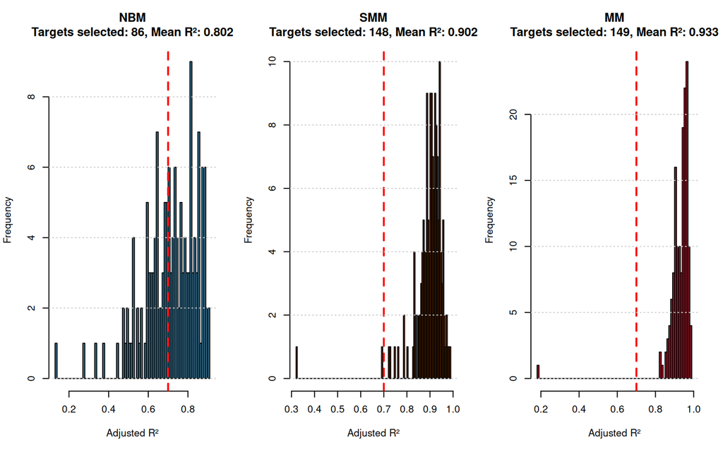

```r
# Plot distribution of adjusted R² values across targets
# Extract Adjusted R squared from SimiC outputs
out <- read_pickle(weights_file)
adjusted_r_squared <- out$adjusted_r_squared
plot_r2_distribution(adjusted_r_squared, simic, grid = c(1, 3),
                     save = FALSE, out_dir = plot_dir)
```

Here we can see that most of the R² values are over 0.7, indicating that the model explains a significant portion of the variance in the target gene expression.

Lower R² might indicate:

- Noisy data
- Missing regulatory interactions
- Complex regulation not captured by linear model

For these targets with low adjusted R2, we suggest to filter them out before plotting. We select a threshold of 0.7 as it was the same used to calculate the activity scores in SimiCPipeline and above. You can change this threshold as needed, but you should re-run the activity score calculation (or SimiCPipeline) with the same threshold to be consistent.

*If you already filtered your weight matrix before creating the SimiCviz object you can skip this part*

```r
# Select targets by adjusted R2
unselected_targets <- list()
selected_targets <- list()
lab_keys <- names(simic@label_names)
for (lab in lab_keys){
    # Save selected for plotting
    selected_targets[[lab]] <- simic@target_ids[which(adjusted_r_squared[[lab]] >= 0.7)]
    # Save unselected for reporting
    label <- simic@label_names[[lab]]
    unselected_targets[[label]] <- simic@target_ids[which(adjusted_r_squared[[lab]] < 0.7)]
}
print("Number of unselected targets per label:")
## [1] "Number of unselected targets per label:"
print(sapply(unselected_targets, length))
## NBM SMM  MM
##  64   2   1
```

## 5.2 Weights Visualization

### 5.2.1 TF Barplots:

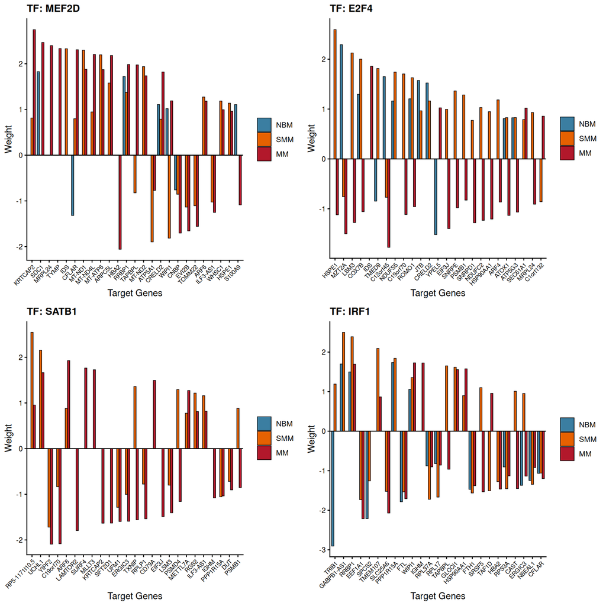

```r
plot_tf_weights(
  simic,
  tf_names = simic@tf_ids[1:4],
  top_n = 25,
  allowed_targets = selected_targets,  # Filter by R² if desired
  grid = c(2, 2),
  save = FALSE,
  out_dir = plot_dir,
  filename = "TF_weights_barplot.pdf"
)
## Plotting 4 TF weight barplot(s)...
```

### 5.2.2 Target Barplots:

Now we will plot the regulators of each target. This plot shows only the TFs with non-zero weights.

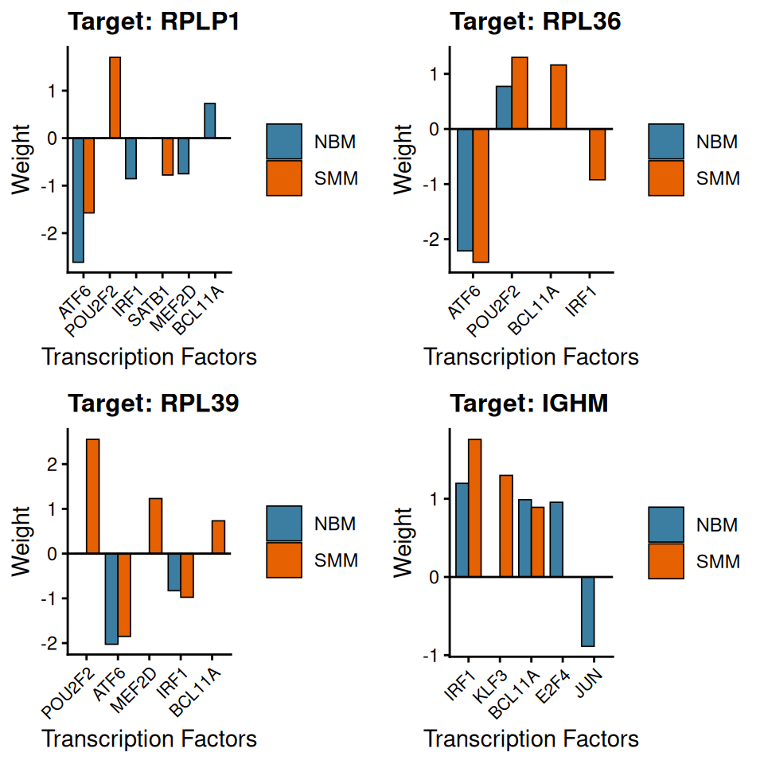

```r
plot_target_weights(
  simic,
  target_names = simic@target_ids[1:4],
  labels = c("NBM", "SMM"),
  grid = c(2, 2),
  save = FALSE,
  out_dir = plot_dir,
  filename = "Target_weights_barplot.pdf"
)
## Plotting 4 target weight barplot(s)...
```

**Note:** If you want to plot all TFs and Targets leave the `tf_names` and target_names arguments respectively blank. ***Note:**: You can also save the output and acces individual plots

```r
all_tfs_barplots <- plot_tf_weights(
                          simic,
                          top_n = 25,
                          grid = NULL,
                          allowed_targets = selected_targets)
```

[figure not shown]

```r
all_tfs_barplots[[1]]
```

### 5.2.3 Regulatory Network Heatmap

You can extract a TF regulon with the function `get_tf_network` and plot it as a heatmap.

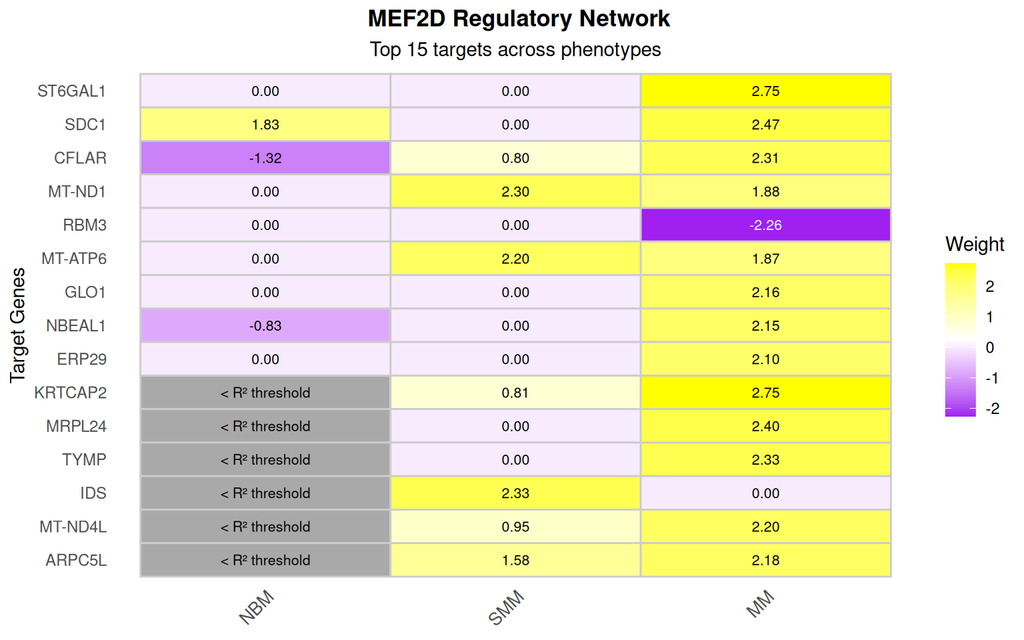

```r
network <- get_tf_network(simic, "MEF2D", r2_threshold = 0.7)
print(head(network))
##               NBM      SMM         MM
## RPLP1  -0.7501612 0.000000  0.0000000
## RPL36   0.0000000 0.000000  0.0000000
## RPL39   0.0000000 1.230387  0.7876861
## IGHM           NA       NA  0.0000000
## EEF1A1  0.0000000 0.000000 -1.0652743
## RPS8    0.0000000 0.000000  0.0000000

plot_tf_network_heatmap(simic, "MEF2D",
                        save = FALSE,
                        top_n = 15,
                        r2_threshold = 0.7,
                        show_values = TRUE,
                        cmap = c("purple","white","yellow"))
```

# Dissimilarity Analysis

To prioritize those TFs of interest, that might be driving the regulatory differences between our groups we perform a dissimilarity analysis by comparing per-cell TF activity-score distributions across phenotype labels using the minmax version of total variation distance for multiple distributions. This metric has values between 0 and 1, with values closer to 0 when the group of distributions is more similar to each other. Consequently, higher scores indicate greater regulatory dissimilarity between conditions — i.e., TFs whose activity differs most across phenotypes.

## 5.3 Global dissimilarity scores

```r
dis_score <- calculate_dissimilarity(simic)
## Calculating dissimilarity scores (all cells)...
## Top 10 TFs by MinMax dissimilarity:
##        MinMax_score
## SATB1     0.9360000
## BCL11A    0.9337778
## POU2F2    0.9191111
## IRF1      0.8471111
## E2F4      0.8271111
## KLF3      0.7417778
## JUN       0.6817778
## MEF2D     0.6608889
## JUND      0.6168889
## ATF6      0.5604444
top_tfs <- rownames(dis_score)
```

## 5.4 Dissimilarity heatmap

We can visualize the top TFs ranked by dissimilarity score in a heatmap fashion.

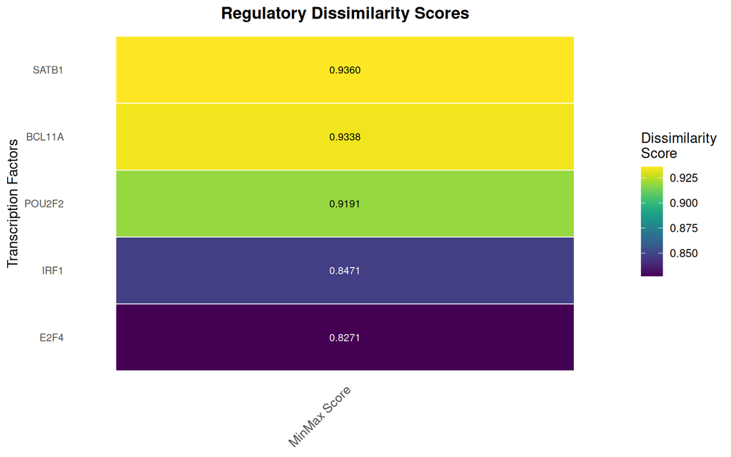

```r
plot_dissimilarity_heatmap(simic,
                           top_n = 5,
                           cmap = "viridis",
                           save = FALSE)
```

Sometimes these transcriptional dynamics are cell-type or cell-cluster specific. In this case, we may want to calculate the dissimilarity scores across the labels within specific cell clusters. For that, we can subset the `SimiCvizExperiment` object by the desired labels and then calculate the dissimilarity scores and plot the heatmap as shown before.

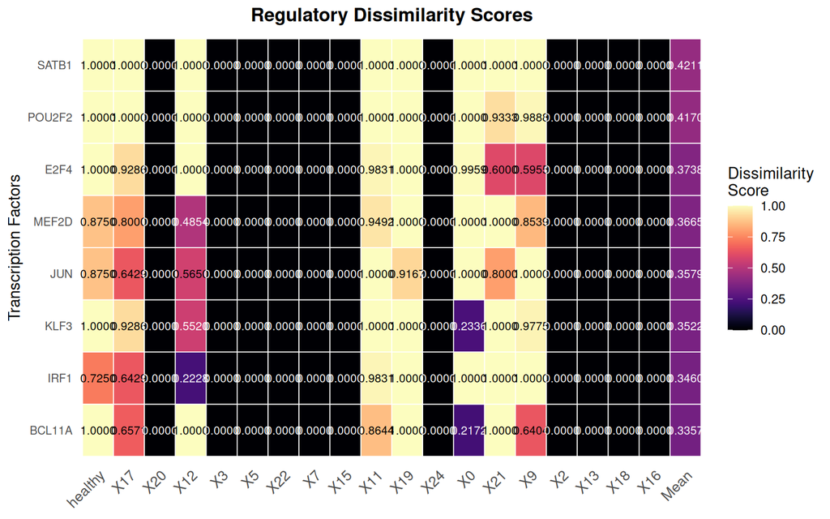

```r
metadata <- read.csv(system.file("extdata/metadata.csv",
  package = "SimiCviz"))

# Build cell groups from metadata (e.g. Seurat clusters, cell types, etc.)
cell_groups  <- lapply(unique(metadata$cluster),
                       function(cluster) {
  cell_labels$cell[metadata$cluster == cluster]
})
names(cell_groups) <- unique(metadata$cluster)

dissim_grouped <- calculate_dissimilarity(simic, labels = c(1,2),
                                          cell_groups = cell_groups)
## Calculating dissimilarity for selected cell groups...
##   Group: healthy (44 cells)
##   Group: 17 (19 cells)
##   Group: 20 (10 cells)
## Warning in calculate_dissimilarity(simic, labels = c(1, 2),
## cell_groups = cell_groups): <2 labels with cells for '20',
## skipping.
##   Group: 12 (71 cells)
##   Group: 3 (212 cells)
## Warning in calculate_dissimilarity(simic, labels = c(1, 2),
## cell_groups = cell_groups): <2 labels with cells for '3',
## skipping.
##   Group: 5 (181 cells)
## Warning in calculate_dissimilarity(simic, labels = c(1, 2),
## cell_groups = cell_groups): <2 labels with cells for '5',
## skipping.
##   Group: 22 (18 cells)
## Warning in calculate_dissimilarity(simic, labels = c(1, 2),
## cell_groups = cell_groups): <2 labels with cells for '22',
## skipping.
##   Group: 7 (144 cells)
## Warning in calculate_dissimilarity(simic, labels = c(1, 2),
## cell_groups = cell_groups): <2 labels with cells for '7',
## skipping.
##   Group: 15 (58 cells)
## Warning in calculate_dissimilarity(simic, labels = c(1, 2),
## cell_groups = cell_groups): <2 labels with cells for '15',
## skipping.
##   Group: 11 (83 cells)
##   Group: 19 (14 cells)
##   Group: 24 (10 cells)
## Warning in calculate_dissimilarity(simic, labels = c(1, 2),
## cell_groups = cell_groups): <2 labels with cells for '24',
## skipping.
##   Group: 0 (245 cells)
##   Group: 21 (19 cells)
##   Group: 9 (91 cells)
##   Group: 2 (181 cells)
## Warning in calculate_dissimilarity(simic, labels = c(1, 2),
## cell_groups = cell_groups): <2 labels with cells for '2',
## skipping.
##   Group: 13 (59 cells)
## Warning in calculate_dissimilarity(simic, labels = c(1, 2),
## cell_groups = cell_groups): <2 labels with cells for '13',
## skipping.
##   Group: 18 (23 cells)
## Warning in calculate_dissimilarity(simic, labels = c(1, 2),
## cell_groups = cell_groups): <2 labels with cells for '18',
## skipping.
##   Group: 16 (18 cells)
## Warning in calculate_dissimilarity(simic, labels = c(1, 2),
## cell_groups = cell_groups): <2 labels with cells for '16',
## skipping.
## Top 10 TFs by mean dissimilarity across groups:
##        healthy       X17 X20       X12 X3 X5 X22 X7 X15
## SATB1    1.000 1.0000000   0 1.0000000  0  0   0  0   0
## POU2F2   1.000 1.0000000   0 1.0000000  0  0   0  0   0
## E2F4     1.000 0.9285714   0 1.0000000  0  0   0  0   0
## MEF2D    0.875 0.8000000   0 0.4853659  0  0   0  0   0
## JUN      0.875 0.6428571   0 0.5650407  0  0   0  0   0
## KLF3     1.000 0.9285714   0 0.5520325  0  0   0  0   0
## IRF1     0.725 0.6428571   0 0.2227642  0  0   0  0   0
## BCL11A   1.000 0.6571429   0 1.0000000  0  0   0  0   0
## ATF6     0.475 0.9285714   0 0.2813008  0  0   0  0   0
## JUND     0.450 0.8571429   0 0.9268293  0  0   0  0   0
##              X11       X19 X24        X0       X21
## SATB1  1.0000000 1.0000000   0 1.0000000 1.0000000
## POU2F2 1.0000000 1.0000000   0 1.0000000 0.9333333
## E2F4   0.9830508 1.0000000   0 0.9959016 0.6000000
## MEF2D  0.9491525 1.0000000   0 1.0000000 1.0000000
## JUN    1.0000000 0.9166667   0 1.0000000 0.8000000
## KLF3   1.0000000 1.0000000   0 0.2336066 1.0000000
## IRF1   0.9830508 1.0000000   0 1.0000000 1.0000000
## BCL11A 0.8644068 1.0000000   0 0.2172131 1.0000000
## ATF6   1.0000000 1.0000000   0 0.9180328 0.6833333
## JUND   0.2507062 1.0000000   0 1.0000000 0.7333333
##               X9 X2 X13 X18 X16 mean_score
## SATB1  1.0000000  0   0   0   0  0.4210526
## POU2F2 0.9887640  0   0   0   0  0.4169525
## E2F4   0.5955056  0   0   0   0  0.3738437
## MEF2D  0.8539326  0   0   0   0  0.3664974
## JUN    1.0000000  0   0   0   0  0.3578718
## KLF3   0.9775281  0   0   0   0  0.3521968
## IRF1   1.0000000  0   0   0   0  0.3459827
## BCL11A 0.6404494  0   0   0   0  0.3357480
## ATF6   1.0000000  0   0   0   0  0.3308547
## JUND   0.9887640  0   0   0   0  0.3266724

# For all labels
plot_dissimilarity_heatmap(simic,
                            cell_groups = cell_groups,
                            top_n = 8,
                            labels=c(1,2),
                            cmap=c("magma"),
                            save = FALSE)
```

We can also select the labels across which we want to compute the dissimilarity score with the argument `labels` and customize the color and sorting options.

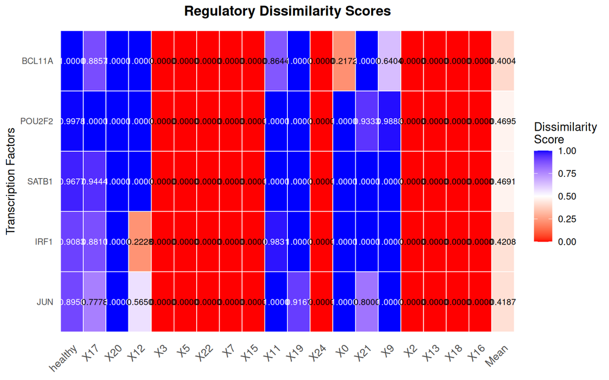

```r
# For labels 0,2
plot_dissimilarity_heatmap(simic,
                            cell_groups = cell_groups,
                            top_n = 5,
                            sort_by = "healthy",
                            cmap=c("red", "white", "blue"),
                            save = FALSE)
```